# Analazing the impact of Satisfaction with financial situation of household effect Feeling of happiness

## **Introduction**:

Happiness is a fundamental aspect of human well-being, and understanding the factors that influence it has long been a subject of study. Among these factors, financial satisfaction plays a significant role, as it impacts an individual’s ability to meet their needs and pursue personal goals. This project explores the relationship between satisfaction with one’s financial situation and feelings of happiness. By analyzing survey data, this study aims to uncover patterns and insights that highlight the importance of financial well-being in shaping happiness.

### **Project Overview**

This project aims to analyze the relationship between household satisfaction with their financial situation and their feelings of happiness. Using a dataset derived from Moroccan households, the study applies various data manipulation, visualization, and geospatial analysis techniques to uncover trends and patterns.

Key questions addressed include:

- Does financial satisfaction significantly influence happiness?
- Are there differences in the relationship between financial satisfaction and happiness in different regions of Morocco?

`(Dependent variable is Y = feelings of happiness, Independent variable X = atisfaction with financial situation of household)`

### **Methodology**

The study employs a structured approach, using Python for data manipulation, statistical analysis, and visualization. The methodology includes:

1. **Data Preparation**: Cleaning and preprocessing the Moroccan dataset to ensure consistency and completeness.
2. **Exploratory Data Analysis (EDA)**: Generating descriptive statistics and visualizations to summarize the dataset and identify initial trends.
3. **Correlation and Regression Analysis**: Examining the statistical relationship between financial satisfaction and happiness.
4. **Geospatial Analysis**: Utilizing GeoPandas to map regional variations in the findings.
5. **Data Visualization**: Leveraging Seaborn, Matplotlib, and Plotly for clear and interactive data presentation.

### **Key Steps**

1. **Data Loading and Cleaning**:
   - Load and view the dataset using `pandas`, `pyreadstat` and `Data Wrangler (vscode extension)`.
   - Handle missing or inconsistent values to prepare for analysis.
2. **Exploratory Data Analysis (EDA)**:
   - Use `pandas`, `numpy` and `statsmodels` for descriptive statistics.
   - Visualize data distributions and relationships using `matplotlib`, `seaborn` `plotly`.
3. **Correlation and Statistical Modeling**:
   - Compute correlation coefficients between financial satisfaction and happiness.
   - Build regression models to quantify the relationship.
4. **Geospatial Analysis**:
   - Use `geopandas` to integrate geographic data.
   - Create visualizations that highlight regional differences across Morocco.
5. **Data Visualization and Insights**:
   - Design static and interactive plots using Plotly to present results.
   - Interpret the findings in the context of Morocco’s socioeconomic landscape.

```python
# Libraries used
#Manipulation/Calucaltion
import pandas as pd
import pyreadstat
import numpy as np
from statsmodels.miscmodels.ordinal_model import OrderedModel
#plotting
import matplotlib.pyplot as plt
import seaborn as sns
import plotly
import plotly.express as px
from plotly.subplots import make_subplots
import plotly.io as pio
#goefileloade/read
import geopandas as gpd
import json
# pandast option setup
pd.set_option('display.max_columns', None)
pd.set_option('display.max_rows', 15)
import warnings
warnings.simplefilter(action='ignore', category=FutureWarning)
```

```python
# Loading the main dataset: df
df, meta = pyreadstat.read_sav('Project_Dataset.sav')
```

```python
df
```

|  | version | doi | A_YEAR | B_COUNTRY | B_COUNTRY_ALPHA | C_COW_NUM | C_COW_ALPHA | D_INTERVIEW | J_INTDATE | FW_START | FW_END | K_TIME_START | K_TIME_END | K_DURATION | Q_MODE | N_REGION_ISO | N_REGION_WVS | N_TOWN | G_TOWNSIZE | G_TOWNSIZE2 | H_SETTLEMENT | H_URBRURAL | I_PSU | O1_LONGITUDE | O2_LATITUDE | S_INTLANGUAGE | LNGE_ISO | E_RESPINT | F_INTPRIVACY | … |
| --- | --- | --- | --- | --- | --- | --- | --- | --- | --- | --- | --- | --- | --- | --- | --- | --- | --- | --- | --- | --- | --- | --- | --- | --- | --- | --- | --- | --- | --- | --- |
| 0 | 0.0 | 0.0 | 2021.0 | 504.0 | MAR | 600.0 | MOR | 504070001.0 | 20211112.0 | 202111.0 | 202112.0 | 10.05 | 10.43 | 38.0 | 2.0 | 504009.0 | 504019.0 | 504099.0 | 1.0 | 1.0 | 4.0 | 2.0 | 99.0 | -8.84 | 29.49 | 170.0 | ar | 1.0 | 2.0 | … |
| 1 | 0.0 | 0.0 | 2021.0 | 504.0 | MAR | 600.0 | MOR | 504070002.0 | 20211112.0 | 202111.0 | 202112.0 | 10.46 | 11.19 | 33.0 | 2.0 | 504009.0 | 504019.0 | 504099.0 | 1.0 | 1.0 | 4.0 | 2.0 | 99.0 | -8.84 | 29.49 | 170.0 | ar | 1.0 | 1.0 | … |
| 2 | 0.0 | 0.0 | 2021.0 | 504.0 | MAR | 600.0 | MOR | 504070003.0 | 20211112.0 | 202111.0 | 202112.0 | 11.28 | 12.09 | 41.0 | 2.0 | 504009.0 | 504019.0 | 504099.0 | 1.0 | 1.0 | 4.0 | 2.0 | 99.0 | -8.84 | 29.49 | 170.0 | ar | 1.0 | 2.0 | … |
| 3 | 0.0 | 0.0 | 2021.0 | 504.0 | MAR | 600.0 | MOR | 504070004.0 | 20211112.0 | 202111.0 | 202112.0 | 12.08 | 12.42 | 34.0 | 2.0 | 504009.0 | 504019.0 | 504099.0 | 1.0 | 1.0 | 4.0 | 2.0 | 99.0 | -8.84 | 29.49 | 170.0 | ar | 1.0 | 1.0 | … |
| 4 | 0.0 | 0.0 | 2021.0 | 504.0 | MAR | 600.0 | MOR | 504070005.0 | 20211112.0 | 202111.0 | 202112.0 | 13.18 | 13.55 | 37.0 | 2.0 | 504009.0 | 504019.0 | 504099.0 | 1.0 | 1.0 | 4.0 | 2.0 | 99.0 | -8.84 | 29.49 | 170.0 | ar | 1.0 | 1.0 | … |
| ... | ... | ... | ... | ... | ... | ... | ... | ... | ... | ... | ... | ... | ... | ... | ... | ... | ... | ... | ... | ... | ... | ... | ... | ... | ... | ... | ... | ... | ... | … |
| 1195 | 0.0 | 0.0 | 2021.0 | 504.0 | MAR | 600.0 | MOR | 504071196.0 | 20211213.0 | 202111.0 | 202112.0 | 14.12 | 15.11 | 59.0 | 2.0 | 504002.0 | 504012.0 | 504081.0 | 5.0 | 3.0 | 3.0 | 1.0 | 81.0 | -2.73 | 34.94 | 170.0 | ar | 1.0 | 1.0 | … |
| 1196 | 0.0 | 0.0 | 2021.0 | 504.0 | MAR | 600.0 | MOR | 504071197.0 | 20211213.0 | 202111.0 | 202112.0 | 15.30 | 16.25 | 55.0 | 2.0 | 504002.0 | 504012.0 | 504081.0 | 5.0 | 3.0 | 3.0 | 1.0 | 81.0 | -2.73 | 34.94 | 170.0 | ar | 2.0 | 1.0 | … |
| 1197 | 0.0 | 0.0 | 2021.0 | 504.0 | MAR | 600.0 | MOR | 504071198.0 | 20211213.0 | 202111.0 | 202112.0 | 16.02 | 17.10 | 68.0 | 2.0 | 504002.0 | 504012.0 | 504081.0 | 5.0 | 3.0 | 3.0 | 1.0 | 81.0 | -2.73 | 34.94 | 170.0 | ar | 1.0 | 1.0 | … |
| 1198 | 0.0 | 0.0 | 2021.0 | 504.0 | MAR | 600.0 | MOR | 504071199.0 | 20211213.0 | 202111.0 | 202112.0 | 17.10 | 18.02 | 52.0 | 2.0 | 504002.0 | 504012.0 | 504081.0 | 5.0 | 3.0 | 3.0 | 1.0 | 81.0 | -2.73 | 34.94 | 170.0 | ar | 1.0 | 2.0 | … |
| 1199 | 0.0 | 0.0 | 2021.0 | 504.0 | MAR | 600.0 | MOR | 504071200.0 | 20211213.0 | 202111.0 | 202112.0 | 17.40 | 18.13 | 34.0 | 2.0 | 504002.0 | 504012.0 | 504081.0 | 5.0 | 3.0 | 3.0 | 1.0 | 81.0 | -2.73 | 34.94 | 170.0 | ar | 1.0 | 1.0 | … |

1200 rows × 430 columns

```python
# setuping the variable view
variable_view = pd.DataFrame({
    "Variable Name": meta.column_names,
    "Label": meta.column_labels,
    "Values": [meta.variable_value_labels.get(var, {}) for var in meta.column_names]
})
```

```python
variable_view.head(10)
```

|  | Variable Name | Label | Values |
| --- | --- | --- | --- |
| 0 | version | Version of Data File | {} |
| 1 | doi | Digital Object Identifier | {} |
| 2 | A_YEAR | Year of survey | {2017.0: '2017', 2018.0: '2018', 2019.0: '2019... |
| 3 | B_COUNTRY | ISO 3166-1 numeric country code | {504.0: 'Morocco'} |
| 4 | B_COUNTRY_ALPHA | ISO 3166-1 alpha-3 country code | {} |
| 5 | C_COW_NUM | CoW country code numeric | {600.0: 'Morocco'} |
| 6 | C_COW_ALPHA | CoW country code alpha | {} |
| 7 | D_INTERVIEW | Interview ID | {} |
| 8 | J_INTDATE | Date of interview | {-5.0: 'No answer; Missing; GB,NIRL: Postal su... |
| 9 | FW_START | Year/month of start-fieldwork | {} |

```python
# seting up the labeled view dataframe: labeled_df
labeled_df = df.copy()
for column, value_labels in meta.variable_value_labels.items():
    if column in labeled_df.columns:
        # Ensure consistent types between DataFrame values and value_labels keys
        value_labels = {float(k): v for k, v in value_labels.items()}  # Convert keys to float
        labeled_df[column] = labeled_df[column].map(value_labels).fillna(labeled_df[column])
```

```python
labeled_df.head(5)
```

|  | version | doi | A_YEAR | B_COUNTRY | B_COUNTRY_ALPHA | C_COW_NUM | C_COW_ALPHA | D_INTERVIEW | J_INTDATE | FW_START | FW_END | K_TIME_START | K_TIME_END | K_DURATION | Q_MODE | N_REGION_ISO | N_REGION_WVS | N_TOWN | G_TOWNSIZE | G_TOWNSIZE2 | H_SETTLEMENT | H_URBRURAL | I_PSU | O1_LONGITUDE | O2_LATITUDE | S_INTLANGUAGE | LNGE_ISO | E_RESPINT | F_INTPRIVACY | … |
| --- | --- | --- | --- | --- | --- | --- | --- | --- | --- | --- | --- | --- | --- | --- | --- | --- | --- | --- | --- | --- | --- | --- | --- | --- | --- | --- | --- | --- | --- | --- |
| 0 | 0.0 | 0.0 | 2021 | Morocco | MAR | Morocco | MOR | 504070001.0 | 20211112.0 | 202111.0 | 202112.0 | 10.05 | 10.43 | 38.0 | Paper-and-Pencil Interviewing (PAPI) | MA-09 Souss-Massa | MA: MA-09 Souss-Massa | MA: Afella Ighir | Under 2,000 | Under 5,000 | Another city, town (not a regional or district... | Rural | 99.0 | -8.84 | 29.49 | Arabic | ar | Respondent was very interested | There were other people around who could follo... | … |
| 1 | 0.0 | 0.0 | 2021 | Morocco | MAR | Morocco | MOR | 504070002.0 | 20211112.0 | 202111.0 | 202112.0 | 10.46 | 11.19 | 33.0 | Paper-and-Pencil Interviewing (PAPI) | MA-09 Souss-Massa | MA: MA-09 Souss-Massa | MA: Afella Ighir | Under 2,000 | Under 5,000 | Another city, town (not a regional or district... | Rural | 99.0 | -8.84 | 29.49 | Arabic | ar | Respondent was very interested | There were no other people around who could fo... | … |
| 2 | 0.0 | 0.0 | 2021 | Morocco | MAR | Morocco | MOR | 504070003.0 | 20211112.0 | 202111.0 | 202112.0 | 11.28 | 12.09 | 41.0 | Paper-and-Pencil Interviewing (PAPI) | MA-09 Souss-Massa | MA: MA-09 Souss-Massa | MA: Afella Ighir | Under 2,000 | Under 5,000 | Another city, town (not a regional or district... | Rural | 99.0 | -8.84 | 29.49 | Arabic | ar | Respondent was very interested | There were other people around who could follo... | … |
| 3 | 0.0 | 0.0 | 2021 | Morocco | MAR | Morocco | MOR | 504070004.0 | 20211112.0 | 202111.0 | 202112.0 | 12.08 | 12.42 | 34.0 | Paper-and-Pencil Interviewing (PAPI) | MA-09 Souss-Massa | MA: MA-09 Souss-Massa | MA: Afella Ighir | Under 2,000 | Under 5,000 | Another city, town (not a regional or district... | Rural | 99.0 | -8.84 | 29.49 | Arabic | ar | Respondent was very interested | There were no other people around who could fo... | … |
| 4 | 0.0 | 0.0 | 2021 | Morocco | MAR | Morocco | MOR | 504070005.0 | 20211112.0 | 202111.0 | 202112.0 | 13.18 | 13.55 | 37.0 | Paper-and-Pencil Interviewing (PAPI) | MA-09 Souss-Massa | MA: MA-09 Souss-Massa | MA: Afella Ighir | Under 2,000 | Under 5,000 | Another city, town (not a regional or district... | Rural | 99.0 | -8.84 | 29.49 | Arabic | ar | Respondent was very interested | There were no other people around who could fo... | … |

```python
# searching for anything that contains the letters that are in Satisfaction
variable_view[variable_view['Label'].str.contains('Sati')]
```

|  | Variable Name | Label | Values |
| --- | --- | --- | --- |
| 82 | Q49 | Satisfaction with your life | {-5.0: 'Other missing; Multiple answers Mail (... |
| 83 | Q50 | Satisfaction with financial situation of house... | {-5.0: 'Missing; Unknown', -4.0: 'Not asked', ... |
| 291 | Q252 | Satisfaction with the political system perform... | {-5.0: 'Other missing; Multiple answers Mail (... |

```python
# searching for anything that contains the letters that are in Happiness
variable_view[variable_view['Label'].str.contains('hap')]
```

|  | Variable Name | Label | Values |
| --- | --- | --- | --- |
| 79 | Q46 | Feeling of happiness | {-5.0: 'Other missing; Multiple answers Mail (... |

```python
# combining the results that we want
DataFrame = pd.DataFrame({
    'Satisfaction with financial situation of household (NV_Q50)': df['Q50'],
    'Feeling of happiness (NV_Q46)': df['Q46'],
    'Feeling of happiness (LV_Q46)': labeled_df['Q46'],
})
```

```python
DataFrame
```

|  | Satisfaction with financial situation of household (NV_Q50) | Feeling of happiness (NV_Q46) | Feeling of happiness (LV_Q46) |
| --- | --- | --- | --- |
| 0 | 6.0 | 2.0 | Quite happy |
| 1 | 2.0 | 4.0 | Not at all happy |
| 2 | 3.0 | 3.0 | Not very happy |
| 3 | 6.0 | 2.0 | Quite happy |
| 4 | 4.0 | 3.0 | Not very happy |
| ... | ... | ... | ... |
| 1195 | 6.0 | 1.0 | Very happy |
| 1196 | 6.0 | 2.0 | Quite happy |
| 1197 | 3.0 | 2.0 | Quite happy |
| 1198 | 3.0 | 2.0 | Quite happy |
| 1199 | 7.0 | 2.0 | Quite happy |

1200 rows × 3 columns

```python
# setting up the frequency table for Feeling of happiness
FoH_frequency_df = DataFrame[['Feeling of happiness (LV_Q46)','Feeling of happiness (NV_Q46)']].value_counts().reset_index().sort_values(by='Feeling of happiness (NV_Q46)')
# calculating the percentages of Feeling of happiness
perFoH = DataFrame[['Feeling of happiness (LV_Q46)']].value_counts(normalize=True)*100
# merge Percentage of Feeling of happiness
FoH_frequency_df = FoH_frequency_df.merge(perFoH, on='Feeling of happiness (LV_Q46)')
#rename the proportion to perFoH
FoH_frequency_df.rename(columns={'proportion':'perFoH'}, inplace=True)
#calculating the mean
mean_SFSH=DataFrame.groupby('Feeling of happiness (LV_Q46)')['Satisfaction with financial situation of household (NV_Q50)'].mean().reset_index().sort_values(by= 'Feeling of happiness (LV_Q46)', ascending=False)
# mearging the mean of Satisfaction with financial situation of household with Feeling of happiness frequency table
FoH_frequency_df=FoH_frequency_df.merge(mean_SFSH, how='left', on='Feeling of happiness (LV_Q46)')

FoH_frequency_df.rename(columns={'Satisfaction with financial situation of household (NV_Q50)':'mean_SFSH'}, inplace=True)
```

```python
FoH_frequency_df
```

|  | Feeling of happiness (LV_Q46) | Feeling of happiness (NV_Q46) | count | perFoH | mean_SFSH |
| --- | --- | --- | --- | --- | --- |
| 0 | Very happy | 1.0 | 149 | 12.416667 | 7.677852 |
| 1 | Quite happy | 2.0 | 845 | 70.416667 | 6.431953 |
| 2 | Not very happy | 3.0 | 195 | 16.250000 | 4.492308 |
| 3 | Not at all happy | 4.0 | 11 | 0.916667 | 2.818182 |

```python
# calculate the mode and median
Mode_FOH = DataFrame['Feeling of happiness (NV_Q46)'].mode()[0] # Get the first mode
Median_FOH = DataFrame['Feeling of happiness (NV_Q46)'].median()

# assign the mode and median to the columns (handling missing values)
FoH_frequency_df['Mode_FOH'] = Mode_FOH
FoH_frequency_df['Median_FOH'] = Median_FOH

# fill any NaN values if needed
FoH_frequency_df['Mode_FOH'].fillna(Mode_FOH, inplace=True)
FoH_frequency_df['Median_FOH'].fillna(Median_FOH, inplace=True)


order = ['Feeling of happiness (LV_Q46)','Feeling of happiness (NV_Q46)','perFoH','Median_FOH','Mode_FOH','count','mean_SFSH']

FoH_frequency_df[order]
```

|  | Feeling of happiness (LV_Q46) | Feeling of happiness (NV_Q46) | perFoH | Median_FOH | Mode_FOH | count | mean_SFSH |
| --- | --- | --- | --- | --- | --- | --- | --- |
| 0 | Very happy | 1.0 | 12.416667 | 2.0 | 2.0 | 149 | 7.677852 |
| 1 | Quite happy | 2.0 | 70.416667 | 2.0 | 2.0 | 845 | 6.431953 |
| 2 | Not very happy | 3.0 | 16.250000 | 2.0 | 2.0 | 195 | 4.492308 |
| 3 | Not at all happy | 4.0 | 0.916667 | 2.0 | 2.0 | 11 | 2.818182 |

```python
Mode_FEC = (
    DataFrame.groupby('Feeling of happiness (LV_Q46)')['Feeling of happiness (NV_Q46)']
    .agg(lambda x: x.mode())
    .reset_index()
    .sort_values(by='Feeling of happiness (LV_Q46)', ascending=False)
    .rename(columns={'Feeling of happiness (NV_Q46)': 'Mode_FEC'})
)

Median_FEC = (
    DataFrame.groupby('Feeling of happiness (LV_Q46)')['Feeling of happiness (NV_Q46)']
    .agg(lambda x: x.median())
    .reset_index()
    .sort_values(by='Feeling of happiness (LV_Q46)', ascending=False)
    .rename(columns={'Feeling of happiness (NV_Q46)': 'Median_FEC'})
)


FoH_frequency_df=FoH_frequency_df.merge(Mode_FEC, how='left',on='Feeling of happiness (LV_Q46)')

FoH_frequency_df=FoH_frequency_df.merge(Median_FEC, how='left',on='Feeling of happiness (LV_Q46)')

FoH_frequency_df
```

|  | Feeling of happiness (LV_Q46) | Feeling of happiness (NV_Q46) | count | perFoH | mean_SFSH | Mode_FOH | Median_FOH | Mode_FEC | Median_FEC |
| --- | --- | --- | --- | --- | --- | --- | --- | --- | --- |
| 0 | Very happy | 1.0 | 149 | 12.416667 | 7.677852 | 2.0 | 2.0 | 1.0 | 1.0 |
| 1 | Quite happy | 2.0 | 845 | 70.416667 | 6.431953 | 2.0 | 2.0 | 2.0 | 2.0 |
| 2 | Not very happy | 3.0 | 195 | 16.250000 | 4.492308 | 2.0 | 2.0 | 3.0 | 3.0 |
| 3 | Not at all happy | 4.0 | 11 | 0.916667 | 2.818182 | 2.0 | 2.0 | 4.0 | 4.0 |

```python
# Create a violing plot
fig = px.violin(
    DataFrame,
    x='Feeling of happiness (LV_Q46)',
    y='Satisfaction with financial situation of household (NV_Q50)',
    box=True,  # Add boxplot overlay
    points='all',  # Show all data points
    title="The value of Satisfaction with financial situation of household based on Feeling of happiness",
    hover_data=['Satisfaction with financial situation of household (NV_Q50)',
                'Feeling of happiness (LV_Q46)']  # Cleaner hover data specification
)

# Update the order of categories
fig.update_layout(
    xaxis=dict(
        categoryorder='array',
        categoryarray=['Not at all happy', 'Not very happy', 'Quite happy', 'Very happy']
    ),
    plot_bgcolor='rgba(240, 240, 240, 1)',  # Light background color
    title_font=dict(size=24, family='Arial', color='black'),  # Title font styling
    xaxis_title='Feeling of happiness',
    yaxis_title='Satisfaction with financial situation of household',
    legend=dict(title='Category', orientation='h', x=0.5, xanchor='center'),
)

# Update the violins for styling
fig.update_traces(
    width=0.5,  # Thinner violins
    line_color='black',  # Black outline
    meanline_visible=True,  # Show mean line
    scalemode='count',  # Adjust width by the count of observations
    fillcolor='rgba(0,0,0,0)',  # Remove fill
)

# Show the plot
fig.show()
```

[output not shown]

```python
#pio.write_html(fig=fig, auto_open='True' ,file='xdplot.html')
```

```python
DataFrame[['Feeling of happiness (NV_Q46)']].corrwith(DataFrame['Satisfaction with financial situation of household (NV_Q50)']).reset_index(name='Satisfaction with financial situation of household')
```

|  | index | Satisfaction with financial situation of household |
| --- | --- | --- |
| 0 | Feeling of happiness (NV_Q46) | -0.438542 |

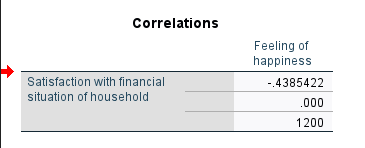

## Fixing the "Feeling of Happiness" Scale

When I calculated the correlation between Feeling of happiness (LV_Q46) and Satisfaction with financial situation of household (NV_Q50), I got a negative result, which didn’t make sense. After checking the data, I realized that the scale for Feeling of happiness (LV_Q46) was flipped meaning higher numbers showed less happiness, and lower numbers showed more happiness.

To fix this, I created a function to reverse the scale, so that higher numbers now represent more happiness. The new scale works like this:

- 1 → 4
- 2 → 3
- 3 → 2
- 4 → 1

which will be:

- 4: Very happy
- 3: Quite happy
- 2: Not very happy
- 1: Not at all happy

I applied this change and added a new column called Feeling of happiness (NV_Q46)_reversed to the dataset. Now, the values are in the correct order for further analysis.

Here’s the function I used to reverse the scale:

```python
# mapping the old scale of Feeling o happiness with new scale
def reverse_happiness(value):
    if pd.notnull(value):  # Ensure the value is not NaN
        mapping = {1: 4, 2: 3, 3: 2, 4: 1}
        return mapping.get(value, value)  # Return mapped value or the value itself if not in mapping
    return value
DataFrame['Feeling of happiness (NV_Q46)_reversed'] = DataFrame['Feeling of happiness (NV_Q46)'].apply(reverse_happiness)
```

```python
DataFrame
```

|  | Satisfaction with financial situation of household (NV_Q50) | Feeling of happiness (NV_Q46) | Feeling of happiness (LV_Q46) | Feeling of happiness (NV_Q46)_reversed |
| --- | --- | --- | --- | --- |
| 0 | 6.0 | 2.0 | Quite happy | 3 |
| 1 | 2.0 | 4.0 | Not at all happy | 1 |
| 2 | 3.0 | 3.0 | Not very happy | 2 |
| 3 | 6.0 | 2.0 | Quite happy | 3 |
| 4 | 4.0 | 3.0 | Not very happy | 2 |
| ... | ... | ... | ... | ... |
| 1195 | 6.0 | 1.0 | Very happy | 4 |
| 1196 | 6.0 | 2.0 | Quite happy | 3 |
| 1197 | 3.0 | 2.0 | Quite happy | 3 |
| 1198 | 3.0 | 2.0 | Quite happy | 3 |
| 1199 | 7.0 | 2.0 | Quite happy | 3 |

1200 rows × 4 columns

```python
DataFrame[['Feeling of happiness (NV_Q46)_reversed']].corrwith(DataFrame['Satisfaction with financial situation of household (NV_Q50)']).reset_index(name='Satisfaction with financial situation of household')
```

|  | index | Satisfaction with financial situation of household |
| --- | --- | --- |
| 0 | Feeling of happiness (NV_Q46)_reversed | 0.438542 |

With this fix, the analysis is now based on the correct Feeling of happiness (NV_Q46)_reversed values, so the results should be more meaningful.

### **What Does a Correlation of 0.44 Mean?**

A correlation of **0.438542** tells us how **Feeling of happiness** and **Satisfaction with financial situation** are related. In simple terms:

- **Positive Correlation**: The positive number means that when people feel more satisfied with their finances, they tend to feel happier too. So, if someone's financial situation improves, their happiness often increases as well.
- **Strength of the Relationship**: A correlation of **0.44** is considered a **moderate** relationship. It's not super strong (like 0.9), but it's not weak either. It shows there's a noticeable link, but it’s not the only thing that matters.
- **What This Means**: This result tells us that financial satisfaction and happiness are connected, but it's not the whole story. While improving financial satisfaction can make people happier, other things like health, relationships, or personal goals might also be affecting how happy they feel.

## Regression and Why I Use Ordinal Regression

**Regression** is a statistical method used to understand the relationship between a dependent variable and one or more independent variables. It helps in predicting the value of the dependent variable based on the independent variables in other words, **Regression** is a method used to understand how different factors (independent variables) affect something we want to predict (dependent variable). It helps us estimate the value of one thing based on others.

### Why Use Ordinal Regression

We use **ordinal regression** when we want to predict outcomes that have **ordered categories**. For example, when predicting levels of happiness, where the categories have a clear order:

- 1: Not at all happy
- 2: Not very happy
- 3: Quite happy
- 4: Very happy

Ordinal regression helps us understand the relationship between independent variables and these ordered categories, while respecting the order of the categories. Unlike other methods, it accounts for the fact that the difference between categories might not be the same (for example, the difference between "Not at all happy" and "Not very happy" might not be the same as between "Quite happy" and "Very happy").

The categories have a natural order, but the distance between them is not necessarily equal. In such cases, **ordinal regression** is the best choice.

### Why Not Linear or Logistic Regression?

- **Linear Regression** assumes the dependent variable is continuous (like height or income) and has equal spacing between values. This is not suitable for ordinal data where the differences between categories may not be equal.
- **Logistic Regression** is used for binary outcomes (yes/no) or for nominal data (multiple categories without order). It doesn’t account for the order of categories, so it’s not appropriate for ordinal data.

```python
# Independent and dependent variables
X = DataFrame[['Satisfaction with financial situation of household (NV_Q50)']]  # Independent variable
y = DataFrame['Feeling of happiness (NV_Q46)_reversed']  # Ordinal dependent variable

# Fit the ordered logit model (ordinal regression)
model = OrderedModel(y, X, distr='logit')  # 'logit' specifies the logit link function
result = model.fit()

# Print the model summary
print(result.summary())

# Predict probabilities for each category
predictions = result.predict(X)

# Convert predictions to a NumPy array
predictions = predictions.to_numpy()

# Create a DataFrame to hold the predicted probabilities for each category
predictions_df = pd.DataFrame(predictions, columns=[f'Prob of Category {i+1}' for i in range(predictions.shape[1])])

# Add the satisfaction variable (X) to the DataFrame for plotting
predictions_df['Satisfaction with financial situation'] = DataFrame['Satisfaction with financial situation of household (NV_Q50)']

# Convert the DataFrame into long format for Plotly Express
predictions_long_df = predictions_df.melt(id_vars=['Satisfaction with financial situation'],
                                        value_vars=[f'Prob of Category {i+1}' for i in range(predictions.shape[1])],
                                        var_name='Category',
                                        value_name='Probability')

# Map the happiness categories to human-readable labels
category_mapping = {0: 'Not at all happy',
                1: 'Not very happy',
                2: 'Quite happy',
                3: 'Very happy'}

# Extract category number from the 'Category' column and map to human-readable labels
predictions_long_df['Happiness Category'] = predictions_long_df['Category'].apply(
    lambda x: category_mapping[int(x.split()[-1])-1])  # map based on the category index (e.g. Category 1 -> Not at all happy)

# Plot the predicted probabilities using Plotly Express
fig = px.scatter(predictions_long_df,
                x='Satisfaction with financial situation',
                y='Probability',
                color='Happiness Category',  # This column contains the mapped labels
                title='Ordinal Regression: Predicted Probabilities of Happiness based on Satisfaction with Financial Situation',
                labels={'Satisfaction with financial situation': 'Satisfaction with Financial Situation',
                        'Probability': 'Predicted Probability',
                        'Happiness Category': 'Happiness Level'})

# Update legend title
fig.update_layout(
    legend_title='Happiness Levels'  # This is the new title for the legend
)

# Show the plot
fig.show()
```

[output not shown]

```
Optimization terminated successfully.
         Current function value: 0.740002
         Iterations: 162
         Function evaluations: 277
                                       OrderedModel Results
==================================================================================================
Dep. Variable:     Feeling of happiness (NV_Q46)_reversed   Log-Likelihood:                -888.00
Model:                                       OrderedModel   AIC:                             1784.
Method:                                Maximum Likelihood   BIC:                             1804.
Date:                                    Tue, 28 Jan 2025
Time:                                            00:45:53
No. Observations:                                    1200
Df Residuals:                                        1196
Df Model:                                               1
===============================================================================================================================
                                                                  coef    std err          z      P>|z|      [0.025      0.975]
-------------------------------------------------------------------------------------------------------------------------------
Satisfaction with financial situation of household (NV_Q50)     0.5065      0.034     14.780      0.000       0.439       0.574
1/2                                                            -2.0937      0.340     -6.157      0.000      -2.760      -1.427
2/3                                                             1.2139      0.090     13.491      0.000       1.038       1.390
3/4                                                             1.4424      0.033     43.198      0.000       1.377       1.508
===============================================================================================================================
```

### Interpretation of the Ordinal Regression Results

### What Was Tested

- **Outcome Variable:** "Feeling of happiness (NV_Q46)_reversed"  
  This is an ordered variable. The term “reversed” suggests that the coding was flipped from the original so that the direction of the scale is switched.
- **Predictor:** "Satisfaction with financial situation of household (NV_Q50)"  
  This variable measures how satisfied people are with their household’s financial situation.

### Key Results

1. **Satisfaction with Financial Situation (NV_Q50):**
   - **Coefficient:** 0.5065  
     A positive coefficient means that as satisfaction increases, the odds of moving to a higher category on the reversed happiness scale also increase.
   - **Statistical Significance:**  
     The very high z-value (14.780) and p-value (0.000) indicate that this relationship is very unlikely to be due to chance.
   - **Interpretation in Odds:**  
     If you exponentiate the coefficient (e^0.5065 ≈ 1.66), it tells us that for each one-unit increase in satisfaction, the odds of being in a higher happiness category increase by about 66%.
2. **Thresholds (Cut-off Points Between Categories):**
   - These values (at -2.0937, 1.2139, and 1.4424) are not predictors but markers that separate the different categories of the happiness variable.
   - They help the model decide where one category ends and the next begins on the latent (hidden) scale that the model estimates.

### Overall Interpretation

Each of the coefficients and thresholds in the table is statistically significant, which means we can be quite confident in these findings based on the sample of 1200 observations.

### **Exploring Regional Differences**

Now that we know financial satisfaction affects happiness, the next step is to check if this relationship changes across different regions of Morocco. By looking at regional patterns, we can see if local factors, like economic conditions or cultural differences, play a role.

In this part, we will use maps and visualizations to explore and compare trends across regions for a clearer understanding.

But before we need to setup the geojson file and dataframe that we will use.

```python
# setupping the map
morocco_data = gpd.read_file("ma.json")
morocco_data.drop(columns='source',inplace=True)
# if the file was in goejson fiormat u need to load t as json format
#morocco_geojson = json.loads(morocco_data.to_json())
```

```python
morocco_data
```

|  | id | name | geometry |
| --- | --- | --- | --- |
| 0 | MA11 | Laâyoune-Sakia El Hamra | POLYGON ((-8.75659 27.14772, -8.75422 27.14715... |
| 1 | MA01 | Tangier-Tetouan-Al Hoceima | POLYGON ((-3.82389 35.19936, -3.82346 35.19887... |
| 2 | MA02 | Oriental | POLYGON ((-3.82012 34.88753, -3.81998 34.89199... |
| 3 | MA08 | Drâa-Tafilalet | POLYGON ((-4.01816 32.60844, -4.00295 32.57946... |
| 4 | MA09 | Souss-Massa | POLYGON ((-7.73179 31.13463, -7.73274 31.13365... |
| 5 | MA10 | Guelmim-Oued Noun | POLYGON ((-8.75659 27.14772, -8.80915 27.16043... |
| 6 | MA06 | Casablanca-Settat | POLYGON ((-9.05932 32.72101, -9.05904 32.7215,... |
| 7 | MA07 | Marrakech-Safi | POLYGON ((-7.18452 31.42896, -7.1929 31.42544,... |
| 8 | MA12 | Dakhla-Oued Ed-Dahab | POLYGON ((-14.90488 24.6832, -14.89861 24.6739... |
| 9 | MA04 | Rabat-Salé-Kenitra | POLYGON ((-6.2434 35.00139, -6.23397 34.99872,... |
| 10 | MA03 | Fez-Meknes | POLYGON ((-5.31515 34.5159, -5.28082 34.51478,... |
| 11 | MA05 | Béni Mellal-Khénifra | POLYGON ((-5.25455 32.86937, -5.25284 32.86344... |

```python
labeled_df['N_REGION_ISO']
```

```
0       MA-09 Souss-Massa
1       MA-09 Souss-Massa
2       MA-09 Souss-Massa
3       MA-09 Souss-Massa
4       MA-09 Souss-Massa
              ...
1195     MA-02 L'Oriental
1196     MA-02 L'Oriental
1197     MA-02 L'Oriental
1198     MA-02 L'Oriental
1199     MA-02 L'Oriental
Name: N_REGION_ISO, Length: 1200, dtype: object
```

```python
# functoin to seperate the region id from its name
id_list = []
regions_name = []
y = labeled_df['N_REGION_ISO'].str.split(' ')
for x in y:
    id_list.append(x[0])
    regions_name.append(x[1])
```

```python
# creating the dataframe the will be ploted 'chromaplot_df'
chromaplot_df = pd.DataFrame({
    'Satisfaction with financial situation of household (NV_Q50)': df['Q50'],
    'Feeling of happiness (NV_Q46)': df['Q46'],
    'Feeling of happiness (NV_Q46)_reversed': DataFrame['Feeling of happiness (NV_Q46)_reversed'],
    'Feeling of happiness (LV_Q46)': labeled_df['Q46'],
    'N_REGION_ISO': labeled_df['N_REGION_ISO'],

})
chromaplot_df['ID_list'] = id_list
chromaplot_df['ID_list']= chromaplot_df['ID_list'].str.replace('-', '')

chromaplot_df['regions_name'] = regions_name
```

```python
chromaplot_df
```

|  | Satisfaction with financial situation of household (NV_Q50) | Feeling of happiness (NV_Q46) | Feeling of happiness (NV_Q46)_reversed | Feeling of happiness (LV_Q46) | N_REGION_ISO | ID_list | regions_name |
| --- | --- | --- | --- | --- | --- | --- | --- |
| 0 | 6.0 | 2.0 | 3 | Quite happy | MA-09 Souss-Massa | MA09 | Souss-Massa |
| 1 | 2.0 | 4.0 | 1 | Not at all happy | MA-09 Souss-Massa | MA09 | Souss-Massa |
| 2 | 3.0 | 3.0 | 2 | Not very happy | MA-09 Souss-Massa | MA09 | Souss-Massa |
| 3 | 6.0 | 2.0 | 3 | Quite happy | MA-09 Souss-Massa | MA09 | Souss-Massa |
| 4 | 4.0 | 3.0 | 2 | Not very happy | MA-09 Souss-Massa | MA09 | Souss-Massa |
| ... | ... | ... | ... | ... | ... | ... | ... |
| 1195 | 6.0 | 1.0 | 4 | Very happy | MA-02 L'Oriental | MA02 | L'Oriental |
| 1196 | 6.0 | 2.0 | 3 | Quite happy | MA-02 L'Oriental | MA02 | L'Oriental |
| 1197 | 3.0 | 2.0 | 3 | Quite happy | MA-02 L'Oriental | MA02 | L'Oriental |
| 1198 | 3.0 | 2.0 | 3 | Quite happy | MA-02 L'Oriental | MA02 | L'Oriental |
| 1199 | 7.0 | 2.0 | 3 | Quite happy | MA-02 L'Oriental | MA02 | L'Oriental |

1200 rows × 7 columns

```python
# calculating  the mean of Feeling of happiness for each region
aggregated_data_FoH = chromaplot_df.groupby(['ID_list','N_REGION_ISO'])['Feeling of happiness (NV_Q46)_reversed'].mean().reset_index()
aggregated_data_FoH
```

|  | ID_list | N_REGION_ISO | Feeling of happiness (NV_Q46)_reversed |
| --- | --- | --- | --- |
| 0 | MA01 | MA-01 Tanger-Tetouan-Al Hoceima | 2.941667 |
| 1 | MA02 | MA-02 L'Oriental | 3.137500 |
| 2 | MA03 | MA-03 Fes-Meknes | 3.020000 |
| 3 | MA04 | MA-04 Rabat-Sale-Kenitra | 2.911765 |
| 4 | MA05 | MA-05 Beni Mellal-Khenifra | 2.812500 |
| 5 | MA06 | MA-06 Casablanca-Settat | 2.934615 |
| 6 | MA07 | MA-07 Marrakech-Safi | 2.893333 |
| 7 | MA08 | MA-08 Draa-Tafilalet | 2.980000 |
| 8 | MA09 | MA-09 Souss-Massa | 2.940000 |
| 9 | MA10 | MA-10 Guelmim-Oued Noun | 2.900000 |
| 10 | MA11 | MA-11 Laayoune-Sakia El Hamra (EH-partial) | 2.800000 |
| 11 | MA12 | MA-12 Dakhla-Oued Ed-Dahab (EH) | 3.000000 |

```python
# calculating  the mean of Satisfaction with financial situation of household for each region
aggregated_data_SFHS = chromaplot_df.groupby(['ID_list','N_REGION_ISO'])['Satisfaction with financial situation of household (NV_Q50)'].mean().reset_index()
aggregated_data_SFHS
```

|  | ID_list | N_REGION_ISO | Satisfaction with financial situation of household (NV_Q50) |
| --- | --- | --- | --- |
| 0 | MA01 | MA-01 Tanger-Tetouan-Al Hoceima | 6.508333 |
| 1 | MA02 | MA-02 L'Oriental | 6.262500 |
| 2 | MA03 | MA-03 Fes-Meknes | 6.766667 |
| 3 | MA04 | MA-04 Rabat-Sale-Kenitra | 6.141176 |
| 4 | MA05 | MA-05 Beni Mellal-Khenifra | 5.975000 |
| 5 | MA06 | MA-06 Casablanca-Settat | 6.080769 |
| 6 | MA07 | MA-07 Marrakech-Safi | 6.033333 |
| 7 | MA08 | MA-08 Draa-Tafilalet | 6.340000 |
| 8 | MA09 | MA-09 Souss-Massa | 6.110000 |
| 9 | MA10 | MA-10 Guelmim-Oued Noun | 6.200000 |
| 10 | MA11 | MA-11 Laayoune-Sakia El Hamra (EH-partial) | 6.850000 |
| 11 | MA12 | MA-12 Dakhla-Oued Ed-Dahab (EH) | 5.400000 |

```python
# updating the chromaplot_df
chromaplot_df = chromaplot_df.merge(aggregated_data_FoH, how='left', on='ID_list')
chromaplot_df = chromaplot_df.merge(aggregated_data_SFHS, how='left', on='ID_list')
chromaplot_df.rename(columns={
    'Feeling of happiness (NV_Q46)_reversed_x': 'Feeling of happiness (NV_Q46)_reversed',
    'Feeling of happiness (NV_Q46)_reversed_y': 'mean_FoH',
    'Satisfaction with financial situation of household (NV_Q50)_x':'Satisfaction with financial situation of household (NV_Q50)',
    'Satisfaction with financial situation of household (NV_Q50)_y':'mean_SFSH'
},
inplace=True)
chromaplot_df
# re-ordering the placement of the columns
reorder=['ID_list','regions_name','N_REGION_ISO','Feeling of happiness (LV_Q46)','Feeling of happiness (NV_Q46)','Feeling of happiness (NV_Q46)_reversed','mean_FoH','Satisfaction with financial situation of household (NV_Q50)','mean_SFSH']
chromaplot_df = chromaplot_df[reorder]
chromaplot_df
```

|  | ID_list | regions_name | N_REGION_ISO | Feeling of happiness (LV_Q46) | Feeling of happiness (NV_Q46) | Feeling of happiness (NV_Q46)_reversed | mean_FoH | Satisfaction with financial situation of household (NV_Q50) | mean_SFSH |
| --- | --- | --- | --- | --- | --- | --- | --- | --- | --- |
| 0 | MA09 | Souss-Massa | MA-09 Souss-Massa | Quite happy | 2.0 | 3 | 2.9400 | 6.0 | 6.1100 |
| 1 | MA09 | Souss-Massa | MA-09 Souss-Massa | Not at all happy | 4.0 | 1 | 2.9400 | 2.0 | 6.1100 |
| 2 | MA09 | Souss-Massa | MA-09 Souss-Massa | Not very happy | 3.0 | 2 | 2.9400 | 3.0 | 6.1100 |
| 3 | MA09 | Souss-Massa | MA-09 Souss-Massa | Quite happy | 2.0 | 3 | 2.9400 | 6.0 | 6.1100 |
| 4 | MA09 | Souss-Massa | MA-09 Souss-Massa | Not very happy | 3.0 | 2 | 2.9400 | 4.0 | 6.1100 |
| ... | ... | ... | ... | ... | ... | ... | ... | ... | ... |
| 1195 | MA02 | L'Oriental | MA-02 L'Oriental | Very happy | 1.0 | 4 | 3.1375 | 6.0 | 6.2625 |
| 1196 | MA02 | L'Oriental | MA-02 L'Oriental | Quite happy | 2.0 | 3 | 3.1375 | 6.0 | 6.2625 |
| 1197 | MA02 | L'Oriental | MA-02 L'Oriental | Quite happy | 2.0 | 3 | 3.1375 | 3.0 | 6.2625 |
| 1198 | MA02 | L'Oriental | MA-02 L'Oriental | Quite happy | 2.0 | 3 | 3.1375 | 3.0 | 6.2625 |
| 1199 | MA02 | L'Oriental | MA-02 L'Oriental | Quite happy | 2.0 | 3 | 3.1375 | 7.0 | 6.2625 |

1200 rows × 9 columns

```python
# grouping the values by ID_list
chromaplot_df.groupby('ID_list')[['regions_name','N_REGION_ISO','mean_FoH','mean_SFSH']].value_counts().reset_index()
```

|  | ID_list | regions_name | N_REGION_ISO | mean_FoH | mean_SFSH | count |
| --- | --- | --- | --- | --- | --- | --- |
| 0 | MA01 | Tanger-Tetouan-Al | MA-01 Tanger-Tetouan-Al Hoceima | 2.941667 | 6.508333 | 120 |
| 1 | MA02 | L'Oriental | MA-02 L'Oriental | 3.137500 | 6.262500 | 80 |
| 2 | MA03 | Fes-Meknes | MA-03 Fes-Meknes | 3.020000 | 6.766667 | 150 |
| 3 | MA04 | Rabat-Sale-Kenitra | MA-04 Rabat-Sale-Kenitra | 2.911765 | 6.141176 | 170 |
| 4 | MA05 | Beni | MA-05 Beni Mellal-Khenifra | 2.812500 | 5.975000 | 80 |
| 5 | MA06 | Casablanca-Settat | MA-06 Casablanca-Settat | 2.934615 | 6.080769 | 260 |
| 6 | MA07 | Marrakech-Safi | MA-07 Marrakech-Safi | 2.893333 | 6.033333 | 150 |
| 7 | MA08 | Draa-Tafilalet | MA-08 Draa-Tafilalet | 2.980000 | 6.340000 | 50 |
| 8 | MA09 | Souss-Massa | MA-09 Souss-Massa | 2.940000 | 6.110000 | 100 |
| 9 | MA10 | Guelmim-Oued | MA-10 Guelmim-Oued Noun | 2.900000 | 6.200000 | 10 |
| 10 | MA11 | Laayoune-Sakia | MA-11 Laayoune-Sakia El Hamra (EH-partial) | 2.800000 | 6.850000 | 20 |
| 11 | MA12 | Dakhla-Oued | MA-12 Dakhla-Oued Ed-Dahab (EH) | 3.000000 | 5.400000 | 10 |

# Mean Feeling of happiness (reversed) for every region

```python
#creating choropleth plots
fig = px.choropleth_mapbox(
    chromaplot_df,
    geojson=morocco_data,
    locations='ID_list',           # Unique region IDs in your DataFrame
    featureidkey="properties.id",  # Matches IDs in GeoJSON
    color='mean_FoH',  # Column to visualize
    hover_name='N_REGION_ISO',  # Column to display region name
    hover_data={
        'N_REGION_ISO' : True
    },
    mapbox_style="carto-positron", # Base map style
    zoom=4,                        # Zoom level
    center={"lat": 31.7917, "lon": -7.0926},  # Center on Morocco
    color_continuous_scale="rdbu",  # Color scale for data visualization
    title="Average Feeling of Happiness in Morocco", # Map title
    range_color=[0, 4]
)
fig.update_layout(
    margin={"r":0,"t":30,"l":0,"b":0}  # Removes excess margins
)
fig.show()
```

[output not shown]

```python
#pio.write_html(fig, file='plot.html', auto_open=True)  # Save and open the plot in a browser
```

```python
# showing the rating of the regions based on the Mean Feeling of happiness (reversed) for every region for every region
chromaplot_df.groupby('ID_list')[['N_REGION_ISO','mean_FoH','mean_SFSH']].value_counts().reset_index().sort_values(by='mean_FoH', ascending=False)
```

|  | ID_list | N_REGION_ISO | mean_FoH | mean_SFSH | count |
| --- | --- | --- | --- | --- | --- |
| 1 | MA02 | MA-02 L'Oriental | 3.137500 | 6.262500 | 80 |
| 2 | MA03 | MA-03 Fes-Meknes | 3.020000 | 6.766667 | 150 |
| 11 | MA12 | MA-12 Dakhla-Oued Ed-Dahab (EH) | 3.000000 | 5.400000 | 10 |
| 7 | MA08 | MA-08 Draa-Tafilalet | 2.980000 | 6.340000 | 50 |
| 0 | MA01 | MA-01 Tanger-Tetouan-Al Hoceima | 2.941667 | 6.508333 | 120 |
| 8 | MA09 | MA-09 Souss-Massa | 2.940000 | 6.110000 | 100 |
| 5 | MA06 | MA-06 Casablanca-Settat | 2.934615 | 6.080769 | 260 |
| 3 | MA04 | MA-04 Rabat-Sale-Kenitra | 2.911765 | 6.141176 | 170 |
| 9 | MA10 | MA-10 Guelmim-Oued Noun | 2.900000 | 6.200000 | 10 |
| 6 | MA07 | MA-07 Marrakech-Safi | 2.893333 | 6.033333 | 150 |
| 4 | MA05 | MA-05 Beni Mellal-Khenifra | 2.812500 | 5.975000 | 80 |
| 10 | MA11 | MA-11 Laayoune-Sakia El Hamra (EH-partial) | 2.800000 | 6.850000 | 20 |

# showing the rating of the regions based on mean of Satisfaction with financial situation of household for every region

```python
#creating choropleth plots
fig = px.choropleth_mapbox(
    chromaplot_df,
    geojson=morocco_data,
    locations='ID_list',           # Unique region IDs in your DataFrame
    featureidkey="properties.id",  # Matches IDs in GeoJSON
    color='mean_SFSH',  # Column to visualize
    hover_name='N_REGION_ISO',  # Column to display region name
    hover_data={
        'N_REGION_ISO' : True,
        'mean_FoH': True
    },
    mapbox_style="carto-positron", # Base map style
    zoom=4,                        # Zoom level
    center={"lat": 31.7917, "lon": -7.0926},  # Center on Morocco
    color_continuous_scale="deep",  # Color scale for data visualization
    title="Average Satisfaction with financial situation of household in Morocco",# Map title
    range_color=[0,10]
    )
fig.update_layout(
    margin={"r":0,"t":30,"l":0,"b":0}  # Removes excess margins
)
fig.show()
```

[output not shown]

```python
#pio.write_html(fig, file='plot.html', auto_open=True)  # Save and open the plot in a browser
```

```python
# showing the rating of the regions based on the Mean of Satisfaction with financial situation of household for every region
chromaplot_df.groupby('ID_list')[['N_REGION_ISO','mean_FoH','mean_SFSH']].value_counts().reset_index().sort_values(by='mean_SFSH', ascending=False)
```

|  | ID_list | N_REGION_ISO | mean_FoH | mean_SFSH | count |
| --- | --- | --- | --- | --- | --- |
| 10 | MA11 | MA-11 Laayoune-Sakia El Hamra (EH-partial) | 2.800000 | 6.850000 | 20 |
| 2 | MA03 | MA-03 Fes-Meknes | 3.020000 | 6.766667 | 150 |
| 0 | MA01 | MA-01 Tanger-Tetouan-Al Hoceima | 2.941667 | 6.508333 | 120 |
| 7 | MA08 | MA-08 Draa-Tafilalet | 2.980000 | 6.340000 | 50 |
| 1 | MA02 | MA-02 L'Oriental | 3.137500 | 6.262500 | 80 |
| 9 | MA10 | MA-10 Guelmim-Oued Noun | 2.900000 | 6.200000 | 10 |
| 3 | MA04 | MA-04 Rabat-Sale-Kenitra | 2.911765 | 6.141176 | 170 |
| 8 | MA09 | MA-09 Souss-Massa | 2.940000 | 6.110000 | 100 |
| 5 | MA06 | MA-06 Casablanca-Settat | 2.934615 | 6.080769 | 260 |
| 6 | MA07 | MA-07 Marrakech-Safi | 2.893333 | 6.033333 | 150 |
| 4 | MA05 | MA-05 Beni Mellal-Khenifra | 2.812500 | 5.975000 | 80 |
| 11 | MA12 | MA-12 Dakhla-Oued Ed-Dahab (EH) | 3.000000 | 5.400000 | 10 |